# Desvantagem salarial dos empregados na hotelaria por região

Glauber Santos

2023-02-06

Este exercício busca analisar a diferença entre o salário médio na hotelaria e nas demais atividades produtivas. Em geral, a remuneração na hotelaria é mais baixa do que no restante da economia. Contudo, a diferença salarial não é homogênea no espaço, sendo mais acentuada em alguns lugares ou regiões.

Para analisar a variação regional da desvantagem salarial dos hoteleiros por região, iremos utilizar dados sobre a remuneração média dos trabalhadores da hotelaria e das demais atividades produtivas por município do Brasil. Compararemos a desvantagem salarial dos hoteleiros nos municípios das regiões Sul e Sudeste do Brasil (mais ricas) com aquela observada nos municípios das demais regiões do país. A ideia é entender se a desvantagem salarial dos hoteleiros é ainda maior nas regiões mais pobres do país.

### Preparação de dados

O salário médio na hotelaria e na economia como um todo será computado a partir de dados do relatório de [Estatísticas do Cadastro Central de Empresas (CEMPRE)] (https://www.ibge.gov.br/estatisticas/economicas/comercio/9016-estatisticas-do-cadastro-central-de-empresas.html) do IBGE. Os dados do número de empregados e a massa salarial de cada município brasileiro por atividade econômica podem ser baixados através da [Tabela 6450](https://sidra.ibge.gov.br/tabela/6450) do banco de dados [SIDRA](https://sidra.ibge.gov.br/) do IBGE.

Para baixar os dados de forma fácil e direta, vamos utilizar o pacote `sidrar`. Para instalar esse pacote, utilize o comando `install.packages("sidrar")`. Depois, execute o comando `get_sidra`. O parâmetro para utilizado nessa função pode ser obtido diretamente no site do SIDRA. Na [Tabela 6450](https://sidra.ibge.gov.br/tabela/6450), selecione as variáveis **Pessoal ocupado assalariado** e **Salários e outras remunerações**, a atividade econômica **55.10-8 Hotéis e similares**, bem como o **Total** das atividades econômicas, o ano de **2019** e **todos os municípios** do país em unidade territorial. O ano de 2019 foi selecionado por ser o mais recente representativo de um momento de não pandemia. Ao invés de clicar em visualizar, vamos selecionar o botão **links de compartilhar** na parte inferior da página. Em seguida, copie o conteúdo de **Parâmetros para a API** a partir do trecho `\t\`. O download pode demorar alguns segundos. Uma vez baixados os dados, vamos dar uma olhada no resultado da importação utilizando o comando `head`.

```r
library(sidrar)

empregos <- get_sidra(api = "/t/6450/n6/all/v/662,708/p/2019/c12762/117546,117897/d/v662%200")

head(empregos, 10)
```

```
##    Nível Territorial (Código) Nível Territorial Unidade de Medida (Código)
## 2                           6         Município                         40
## 3                           6         Município                         40
## 4                           6         Município                         45
## 5                           6         Município                         45
## 6                           6         Município                         40
## 7                           6         Município                         40
## 8                           6         Município                         45
## 9                           6         Município                         45
## 10                          6         Município                         40
## 11                          6         Município                         40
##    Unidade de Medida  Valor Município (Código)                  Município
## 2          Mil Reais    101            1100015 Alta Floresta D'Oeste - RO
## 3          Mil Reais  58805            1100015 Alta Floresta D'Oeste - RO
## 4            Pessoas      8            1100015 Alta Floresta D'Oeste - RO
```

[output cut: 40 more lines]

Note que cada município consta em quatro linhas diferentes e todos os valores estão na mesma variável intitulada “Valor”. Veja que o objeto “empregos” tem 22280 linhas, mas o Brasil tem apenas 5570 municípios. Cada linha se refere a uma combinação de número de empregados ou massa salarial (Variável) e hotelaria ou economia como um todo (Classificação CNAE). Para calcular os salários médios e a diferença salarial dos hoteleiros, é conveniente que os quatro valores estejam em variáveis separadas e que cada município conste em apenas uma linha. Vamos fazer isso utilizando o comando `pivot_wider`. Antes disso, temos que carregar o pacote `tidyverse`. Se você ainda não tem esse pacote instalado, utilize o comando `install.packages`.

```r
library(tidyverse)

empregos <- pivot_wider(empregos,
                         names_from = c("Classificação Nacional de Atividades Econômicas (CNAE 2.0)", "Variável"),
                         values_from = Valor,
                         id_cols = c("Município (Código)", "Município"))

head(empregos)
```

```
## # A tibble: 6 × 6
##   `Município (Código)` Município                 55.10…¹ Total…² 55.10…³ Total…⁴
##   <chr>                <chr>                       <dbl>   <dbl>   <dbl>   <dbl>
## 1 1100015              Alta Floresta D'Oeste - …     101   58805       8    2443
## 2 1100023              Ariquemes - RO                 NA  440332      NA   16718
## 3 1100031              Cabixi - RO                    NA   13352      NA     536
## 4 1100049              Cacoal - RO                  3303  436894     222   17058
## 5 1100056              Cerejeiras - RO               333   50928      25    2022
## 6 1100064              Colorado do Oeste - RO         NA   47580      NA    2110
## # … with abbreviated variable names
## #   ¹`55.10-8 Hotéis e similares_Salários e outras remunerações`,
## #   ²`Total_Salários e outras remunerações`,
## #   ³`55.10-8 Hotéis e similares_Pessoal ocupado assalariado`,
## #   ⁴`Total_Pessoal ocupado assalariado`
```

Agora temos uma tabela no formato desejado. Note que apenas as colunas relevantes da tabela foram mantidas, sendo as demais descartadas em meio ao uso do comando `pivot_wider`. Note também que agora a tabela empregos passou a ter 5570 linhas, o que equivale ao número de municípios do país.

Em seguida, vamos calcular o salário médio na hotelaria e na economia como um todo para cada município do país. Nos municípios em que não há registro de empregados no setor hoteleiro, o número de empregados e a massa salarial constam como `NA` (não disponível). O resultado do cálculo do salário médio nesses casos também será `NA`. Após o cálculo dos salários médios, vamos calcular a diferença salarial percentual.

```r
empregos$salmed_hotel <- empregos$`55.10-8 Hotéis e similares_Salários e outras remunerações` / empregos$`55.10-8 Hotéis e similares_Pessoal ocupado assalariado`

empregos$salmed_geral <- empregos$`Total_Salários e outras remunerações` / empregos$`Total_Pessoal ocupado assalariado`

empregos$diferenca_salarial <- empregos$salmed_hotel/empregos$salmed_geral-1

head(empregos)
```

```
## # A tibble: 6 × 9
##   Município (C…¹ Munic…² 55.10…³ Total…⁴ 55.10…⁵ Total…⁶ salme…⁷ salme…⁸ difer…⁹
##   <chr>          <chr>     <dbl>   <dbl>   <dbl>   <dbl>   <dbl>   <dbl>   <dbl>
## 1 1100015        Alta F…     101   58805       8    2443    12.6    24.1  -0.476
## 2 1100023        Arique…      NA  440332      NA   16718    NA      26.3  NA
## 3 1100031        Cabixi…      NA   13352      NA     536    NA      24.9  NA
## 4 1100049        Cacoal…    3303  436894     222   17058    14.9    25.6  -0.419
## 5 1100056        Cereje…     333   50928      25    2022    13.3    25.2  -0.471
## 6 1100064        Colora…      NA   47580      NA    2110    NA      22.5  NA
## # … with abbreviated variable names ¹`Município (Código)`, ²Município,
## #   ³`55.10-8 Hotéis e similares_Salários e outras remunerações`,
## #   ⁴`Total_Salários e outras remunerações`,
## #   ⁵`55.10-8 Hotéis e similares_Pessoal ocupado assalariado`,
## #   ⁶`Total_Pessoal ocupado assalariado`, ⁷salmed_hotel, ⁸salmed_geral,
## #   ⁹diferenca_salarial
```

Podemos ver o resultado na última coluna da tabela. Note que os valores estão registrados em decimais. No município 1100015, por exemplo, os empregados na hotelaria ganham, em média, 47,55% a menos do que os empregados da economia como um todo.

Por fim, vamos criar uma variável para identificar os municípios das regiões Sul e Sudeste do país. A região do país pode ser identificada pelo primeiro dígito do código do município. Municípios da região Norte começam com o dígito 1, Nordeste 2, Sudeste 3, Sul 4 e Centro Oeste 5. Sendo assim, vamos primeiro criar uma variável identificando a região e depois diferenciar Sul e Sudeste das demais regiões. Para tanto, será preciso considerar o código do município como variável numérica, embora originalmente ela tenha sido importada como texto.

```r
empregos$regiao <- floor(as.numeric(empregos$`Município (Código)`)/1000000)

empregos$sulsudeste <- ifelse((empregos$regiao==3 | empregos$regiao==4), 1, 0)

head(empregos)
```

```
## # A tibble: 6 × 11
##   Munic…¹ Munic…² 55.10…³ Total…⁴ 55.10…⁵ Total…⁶ salme…⁷ salme…⁸ difer…⁹ regiao
##   <chr>   <chr>     <dbl>   <dbl>   <dbl>   <dbl>   <dbl>   <dbl>   <dbl>  <dbl>
## 1 1100015 Alta F…     101   58805       8    2443    12.6    24.1  -0.476      1
## 2 1100023 Arique…      NA  440332      NA   16718    NA      26.3  NA          1
## 3 1100031 Cabixi…      NA   13352      NA     536    NA      24.9  NA          1
## 4 1100049 Cacoal…    3303  436894     222   17058    14.9    25.6  -0.419      1
## 5 1100056 Cereje…     333   50928      25    2022    13.3    25.2  -0.471      1
## 6 1100064 Colora…      NA   47580      NA    2110    NA      22.5  NA          1
## # … with 1 more variable: sulsudeste <dbl>, and abbreviated variable names
## #   ¹`Município (Código)`, ²Município,
## #   ³`55.10-8 Hotéis e similares_Salários e outras remunerações`,
## #   ⁴`Total_Salários e outras remunerações`,
## #   ⁵`55.10-8 Hotéis e similares_Pessoal ocupado assalariado`,
## #   ⁶`Total_Pessoal ocupado assalariado`, ⁷salmed_hotel, ⁸salmed_geral,
## #   ⁹diferenca_salarial
```

### Análise de dados

Vamos começar a exploração dos dados com medidas descritivas da diferença salarial da hotelaria por região. Para calcular estatísticas, vamos utilizar o pacote `rstatix`.

```r
library(rstatix)

empregos %>%
  group_by(sulsudeste) %>%
  get_summary_stats(diferenca_salarial, type = "mean_sd")
```

```
## # A tibble: 2 × 5
##   sulsudeste variable               n   mean    sd
##        <dbl> <fct>              <dbl>  <dbl> <dbl>
## 1          0 diferenca_salarial   548 -0.389 0.212
## 2          1 diferenca_salarial   746 -0.324 0.174
```

Os cálculos mostram que os empregados na hotelaria ganham cerca de 32,4% a menos do que a média dos trabalhadores na região Sul/Sudeste. No restante do país, a desvantagem salarial na hotelaria chega a 38,9%. A heterogeneidade da diferença salarial entre municípios é menor na região Sul/Sudeste, pois o desvio padrão (sd) é menor nessa parte do país.

Os dados da diferença salarial da hotelaria por região podem ser visualizados no gráfico boxplot apresentado a seguir.

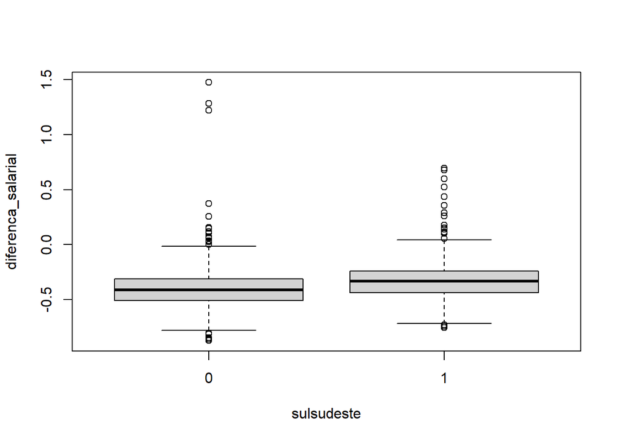

```r
boxplot(diferenca_salarial ~ sulsudeste, data = empregos)
```

Os dados observados revelam uma realidade concreta, permitindo-nos elaborar um enunciado particular. Contudo, na ciência, geralmente estamos interessados em enunciados gerais. A partir da análise concreta, não podemos saber se a desvantagem salarial é menor nas regiões Sul e Sudeste em razão de uma simples distribuição aleatória de valores entre municípios, ou se efetivamente podemos atribuir essa diferença à região. Para afirmar que a diferença é devida à região, temos que comparar a diferença de médias com aquela que seria esperada se as realidades municipais fossem aleatoriamente distribuídas no país. Em outras palavras, vamos testar a hipótese:

H1: A desvantagem salarial dos hoteleiros é menor nas regiões mais ricas do que nas regiões mais pobres.

A hipótese nula referente a H1 pode ser redigida como:

H0: A desvantagem salarial dos hoteleiros é a mesma nas regiões mais ricas e nas regiões mais pobres.

Para tanto, vamos começar testando a normalidade da distribuição de municípios segundo o valor da desvantagem salarial de hoteleiros.

```r
empregos %>%
  group_by(sulsudeste) %>%
  shapiro_test(diferenca_salarial)
```

```
## # A tibble: 2 × 4
##   sulsudeste variable           statistic        p
##        <dbl> <chr>                  <dbl>    <dbl>
## 1          0 diferenca_salarial     0.802 2.45e-25
## 2          1 diferenca_salarial     0.936 2.29e-17
```

Os resultados indicam que as distribuições das duas partes do país se afastam da distribuição Normal, confirmando a impressão de assimetria positiva sugerida pelo boxplot. Uma alternativa a ser examinada neste caso é a consideração do logaritmo da diferença salarial.

```r
empregos$log_diferenca_salarial <- log(empregos$diferenca_salarial)
empregos %>%
  group_by(sulsudeste) %>%
  shapiro_test(log_diferenca_salarial)
```

```
## # A tibble: 2 × 4
##   sulsudeste variable               statistic     p
##        <dbl> <chr>                      <dbl> <dbl>
## 1          0 log_diferenca_salarial     0.950 0.520
## 2          1 log_diferenca_salarial     0.948 0.248
```

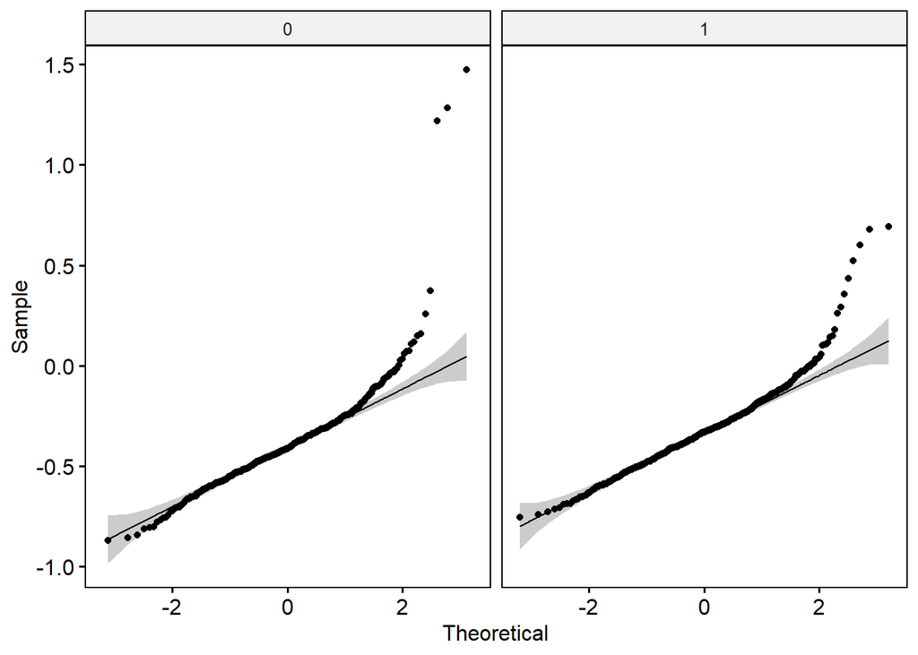

```r
library(ggpubr)
ggqqplot(empregos, x = "diferenca_salarial", facet.by = "sulsudeste")
```

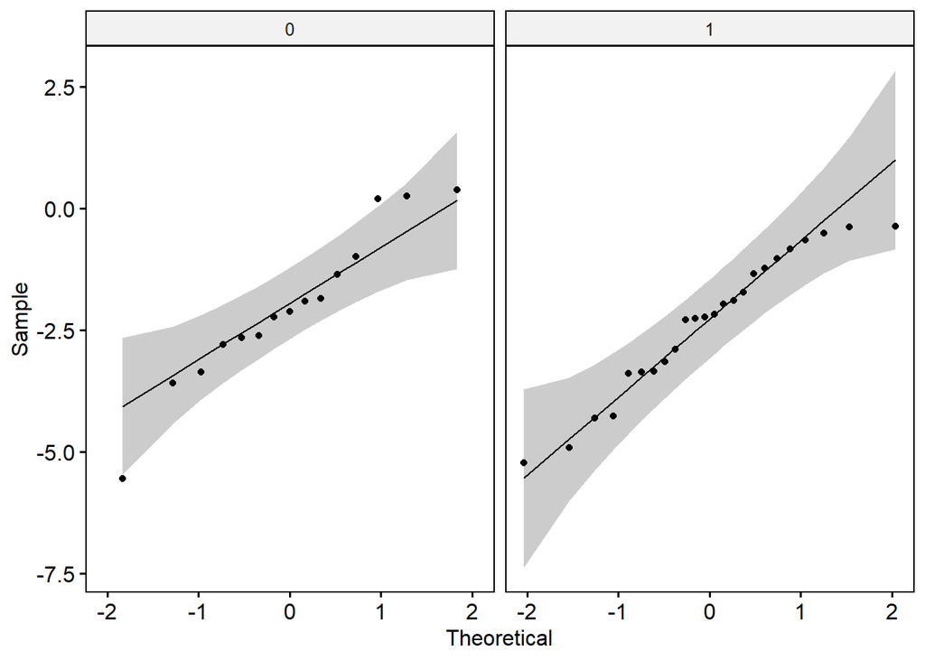

```r
ggqqplot(empregos, x = "log_diferenca_salarial", facet.by = "sulsudeste")
```

Além da normalidade, a escolha do teste de médias requer a análise da igualdade de variâncias da desvantagem salarial para os dois grupos em questão. A igualdade das variâncias para as duas partes do país é analisada com auxílio do teste de Levene.

```r
empregos$sulsudeste <- as.character(empregos$sulsudeste)
empregos %>% levene_test(log_diferenca_salarial ~ sulsudeste)
```

```
## # A tibble: 1 × 4
##     df1   df2 statistic     p
##   <int> <int>     <dbl> <dbl>
## 1     1    37   0.00426 0.948
```

O resultado do teste de igualdade de variâncias indica que a hipótese de igualdade não deve ser descartada. Sendo assim, para a comparação de médias, utiliza-se o teste t de Student, que assume variâncias iguais entre os dois grupos.

```r
empregos %>%
  t_test(log_diferenca_salarial ~ sulsudeste, var.equal = TRUE) %>%
  add_significance()
```

```
## # A tibble: 1 × 9
##   .y.                    group1 group2    n1    n2 statistic    df     p p.sig…¹
##   <chr>                  <chr>  <chr>  <int> <int>     <dbl> <dbl> <dbl> <chr>
## 1 log_diferenca_salarial 0      1         15    24     0.630    37 0.533 ns
## # … with abbreviated variable name ¹p.signif
```

Os resultados apontam que a diferença entre regiões no logaritmo da diferença salarial não é significante, sugerindo a rejeição de H1 e a aceitação de H0. Logo, conclui-se que não há evidências para descartar a hipótese de qeu a desvantagem salarial dos empregados do turismo é a mesma nas regiões Sul e Sudeste e no restante do país.

Por fim, apenas a título de exemplo, já que o teste t revelou a igualdade de médias, estima-se a dimensão da diferença encontrada entre as duas partes do país. Utilizando-se a estatística d de Cohen, conclui-se que o tamanho do efeito é 0,207, valor que é tradicionalmente classificado como pequeno.

```r
empregos %>%  cohens_d(log_diferenca_salarial ~ sulsudeste, var.equal = TRUE)
```

```
## # A tibble: 1 × 7
##   .y.                    group1 group2 effsize    n1    n2 magnitude
## * <chr>                  <chr>  <chr>    <dbl> <int> <int> <ord>
## 1 log_diferenca_salarial 0      1        0.207    15    24 small
```

#### Referência

https://www.datanovia.com/en/lessons/t-test-in-r/